# Beeswarm charts

# When to use beeswarm charts

Beeswarm or jitter charts are excellent for comparing a continuous variable across multiple categories. Beeswarm charts are essentially dot plots where the dots are randomly moved horizontally (in a vertical beeswarm) or vertically (in a horizontal beeswarm) to more effectively show the distribution of points across a continuous variable.

If you’re planning to use a box plot, consider upgrading to a beeswarm or overlaying a beeswarm on a box plot.

This code was adapted from Stephanie Evergreen’s Code for Beeswarm Plots. [This article](https://stephanieevergreen.com/ways-to-make-more-inclusive-data-viz/) goes over the motivation for using a beeswarm plot in detail.

# R code

Get the packages you need

```r
library(dplyr)
library(ggplot2)
library(ggtext)
library(grid)
library(gridExtra)
library(extrafont)
library(smcepi)
```

Load the data. For these charts, we’ll use the R dataset called `iris`. This data set has measurements for three different species of iris.

```r
data(iris)
```

## General information

This code is quite similar to the code for creating a dot plot. However, when creating beeswarm plots you should pay close attention to the the `position_jitter()` and `alpha` arguments.

`position_jitter()`: here you can set a maximum random horizontal or vertical movement for a given point. To maintain distinction between categories, the value you put here should be less than 1/2 (a more thorough explanation for that is [here](https://ggplot2.tidyverse.org/reference/position_jitter.html)). For a vertical chart, use horizontal jitter, ex: `w = 1/3` and for a horizontal chart, use vertical jitter, ex: `h = 1/3`.

`alpha`: this controls the transparency of each point. 0 is completely transparent and 1 is completely opaque. You want the alpha value to be somewhere between 0 and 1 so you can see the density of points in the chart.

## Vertical beeswarm chart

In this example, `x` is our categorical variable and `y` is our continuous variable. In `position_jitter()` `w = 1/4` which means the dots will be randomly “jittered” horizontally. Setting `h = 0` just means that all points will be at their assigned `y` value.

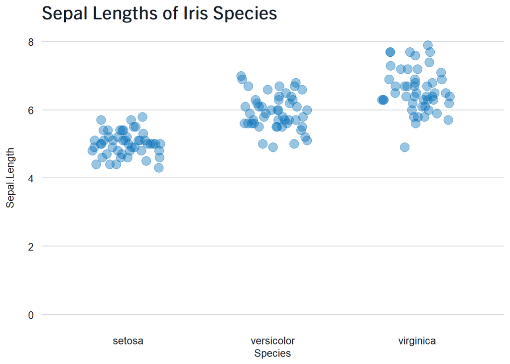

```r
# vertical beeswarm ----
## make plot ----
title <- "Sepal Lengths of Iris Species"

iris %>%
  ggplot(aes(x = Species,
             y = Sepal.Length)) +
  geom_point(
    position = position_jitter(w = 1/4, h = 0),
    size = 4,
    color = "#006cb6",
    alpha = 0.4
  ) +
  scale_y_continuous(
    limits = c(0, 8),
    breaks = seq(0, 8, 2)
  ) +
  labs(title = title) +
  theme_gg_smc()
```

## Horizontal beeswarm chart

You might prefer to have the continuous variable on the x-axis. If so, you can easily change the code above. You just need to:

- swap the `x` and `y` variables in `ggplot()`
- swap the `h` and `w` arguments in `position_jitter()`
- use `scale_x_continuous` instead of `scale_y_continuous`

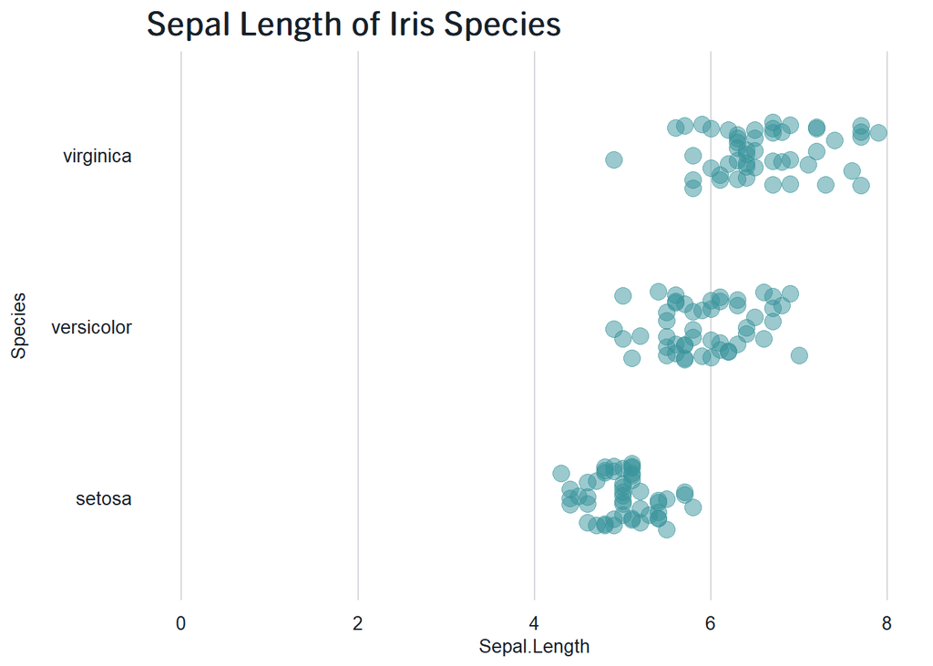

```r
iris %>%
  ggplot(aes(x = Sepal.Length,
             y = Species)) +
  geom_point(
    position = position_jitter(h = 1/5, w = 0),
    size = 4,
    color = "#38939b",
    alpha = 1/2
  ) +
  scale_x_continuous(
    limits = c(0, 8),
    breaks = seq(0, 8, 2)
  ) +
  labs(title = "Sepal Length of Iris Species") +
  theme_gg_smc(plot_lines = "vertical")
```